# 0 Data Sources for Infectious Diseases

Stefan Scholz

2022-09-12

## Background

The German health care system can be described as fragmented (see Figure 1). Unfortunately, this affects the availability of health-care related data.

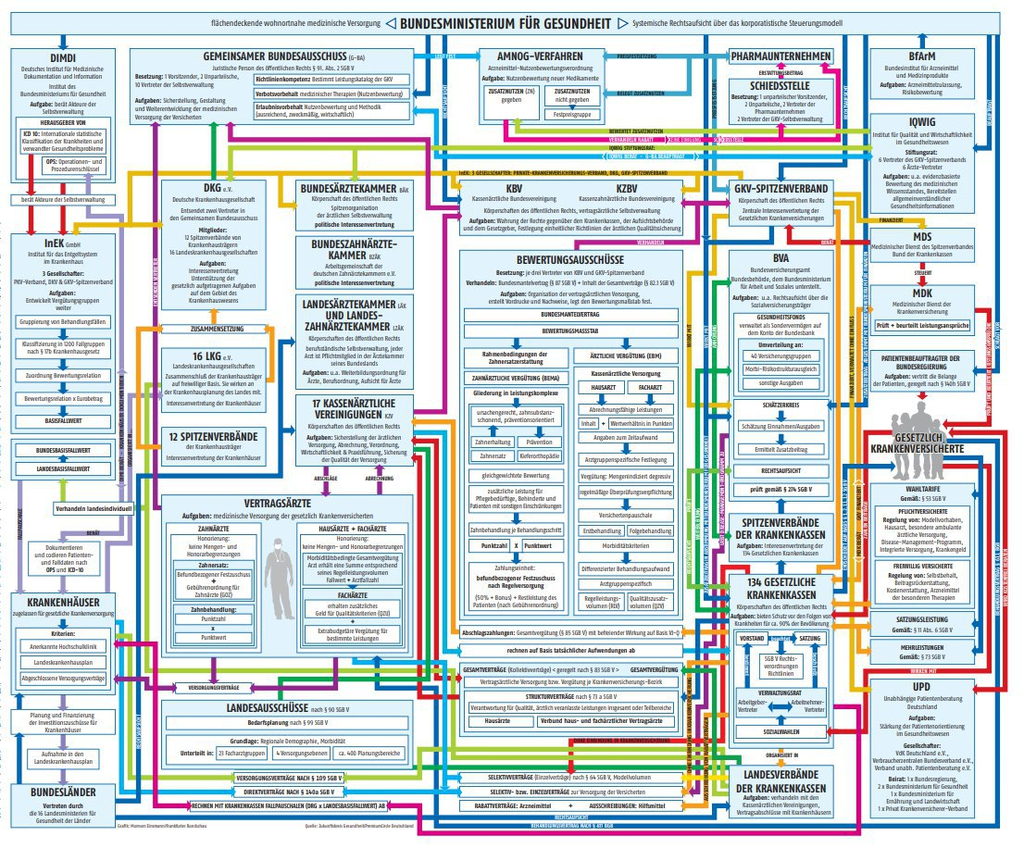

Figure 1: The German health care system. Source: Frankfurter Rundschau, 2014

Data availability for COVID-19 is not representative for the general availability and accessibility of data needed for infectious data modeling. It can be assumed that data availability will rather return to pre-COvID levels than for all other disease to reach levels of availability of COVID-related data.

This initial exercise will therefore not cover COVID data sources, but show you the main publicly available data sources that provide data on the epidemiology of all other infectious diseases.

### Public data sources (immediately accessible)

- [DESTATIS Genesis database](https://www-genesis.destatis.de/genesis/online)
- [DESTATIS Regional database](https://www.regionalstatistik.de/genesis/online/)
- [GBE Bund](https://www.gbe-bund.de/gbe/)
- [Robert Koch-Insitute](https://www.rki.de)
- [SurvStat](https://survstat.rki.de/)
- [VaccMap](http://www.vacmap.de/)
- [BfArM](https://www.bfarm.de/)
- [BfArM ICD-10 Catalogue](https://www.bfarm.de/DE/Kodiersysteme/Klassifikationen/ICD/ICD-10-GM/_node.html)
- [Versorgungsatlas](https://www.versorgungsatlas.de/)

### Public data sources (accessible via request)

- [Forschungsdatenzentrum Gesundheit](https://www.forschungsdatenzentrum-gesundheit.de/)
- [DESTATIS databases](https://www.forschungsdatenzentrum.de/de/gesundheit)

### Restricted data sources (regularly publishing reports or via request)

- [ZI - Zentralinstitut für die Kassenärztliche Versorgung in Deutschland](https://www.zi.de/)
- [RKI Vaccine Surveillance](https://www.rki.de/DE/Content/Infekt/Impfen/Impfstatus/kv-impfsurveillance/kvis_node.html)

### Mandatory Exercises

The exercise will look at the epidemiology of Invasive Meningococcal Disease (IMD; *invasive Meningokokkenerkrankung*).

- Get a rough idea about IMD (e.g., the pathogen, the transmission route and the symptoms).
- Try to find the administrative ICD-10 codes used for IMD in Germany
  - Look at other (neighboring) ICD-codes. Can you identify similarities in the coding system across the different diseases?
- Go to the **SurvStat** database and look for IMD
  - How can the pathogen be stratified?
  - Do you see any patterns across the years or within a year?
  - Try to find a way to view data for each week (Kalenderwoche) of 2018 and 2019
  - Download data for all IMD cases in 2019 stratified by age groups (*Kinder fein stratifiziert*)
- Go to **GBE Bund** and search for the ICD-code of IMD
  - Try to find a modifiable table (*Tabelle (gestaltbar)*) for the inpatient diagnoses by location of residence (*nach Wohnart*)
  - Try to modify the table to display all IMD cases (use the 3-digit ICD) by age and year. Try to select age groups that match the SurvStat age groups.
  - Download data for all IMD cases in 2019 stratified by age groups
- Calculate the hospitalization rates for IMD cases in 2019 stratified by age. What pattern can you see? What can be factors causing this pattern?

### Advanced Exercises

- Discuss whether this data seems sufficient inform a dynamic transmission model. What aspects of the disease transmission seem critical to you to properly model IMD?
- Go to [PubMed](https://pubmed.ncbi.nlm.nih.gov/) or [google scholar](https://scholar.google.com/) and look for models on IMD in Germany and see what data they used, what types of models they built and if the aspects you deemed critical are included in the models.